# Report for Coding project 4: L1-regularized linear models for regression and binary classification.

Sixian Zhang, Zaoyi Chi, Hao Wang, Huayu Li

2019-05-04

## Introduction

For this project you will be writing an R package that implements optimization algorithms for linear models with L1-regularization.

Here are some significant formulas that have been used in this function:

**Loss:**

**1.Regression:** $\frac{1}{2}||X_w-y||^2_2 , \forall{R^u}$

**2.Binary classification:** $L(w) = \sum^{n}_{i=1}log[1+exp(-\tilde{y}_if(x_i))] , \forall{y_i} \epsilon\{0,1\}$

**Cost:**

**1.Regression:** $C(w) = \frac{1}{2}||X_w-y||^2_2 + \lambda||w||_1$

**2.Binary classification:** $C(w) = \sum^{n}_{i=1}log[1+exp(-\tilde{y}_if(x_i))] + \lambda||w||_1$

**Proximal Gradient Algorithm:**

**1.Step direction:** $d^{t)} = -\nabla L(w^{(0)})$

**2.Intermediate step:** $u^{(t)} = w^{(t)}+\alpha^{(t)}d^{(t)}$

**3.Proximal operator**$w^{(t+1)} = Prox_{x^{(t)}R(z)} = argmin_z(\alpha^{(t)}R(z)+\frac{1}{2}||z-u^{(t)}||^2_2)$

## Main Function

The purpose of this section is to give users a general information of this package. We will briefly go over the main functions.

```r
library(LinearModelL1)
library(ElemStatLearn)
data(spam, package = "ElemStatLearn")
data(SAheart, package = "ElemStatLearn")
data(zip.train, package = "ElemStatLearn")
zip.train <- zip.train[zip.train[, 1] %in% c(0, 1),]
data(prostate, package = "ElemStatLearn")
data(ozone, package = "ElemStatLearn")

data.list <- list(
  spam = list(
    features = as.matrix(spam[, 1:57]),
    labels = ifelse(spam$spam == "spam", 1, 0),
    is.01 = TRUE,
    step.size = 0.1,
    lmax = 0.3
  ),

  SAheart = list(
    features = as.matrix(SAheart[, c(1:4, 6:9)]),
    labels = SAheart$chd,
    is.01 = TRUE,
    step.size = 0.1,
    lmax = 0.2
  ),

  zip.train = list(
    features = as.matrix(zip.train[, -1]),
    labels = zip.train[, 1],
    is.01 = TRUE,
    step.size = 0.1,
    lmax = 0.5
  ),


  prostate = list(
    features = as.matrix(prostate[, 1:8]),
    labels = prostate$lpsa,
    is.01 = FALSE,
    step.size = 0.1,
    lmax = 1
  ),

  ozone = list(
    features = as.matrix(ozone[,-1]),
    labels = ozone[, 1],
    is.01 = FALSE,
    step.size = 0.01,
    lmax = 21
  )
)

n.folds <- 5L
```

## Experiments/application

We are going to run our code on the following data sets.

## Data set 1: spam

```r
data.name = 1
data.set <- data.list[[data.name]]

test.loss.mat <- matrix(0, nrow = n.folds, ncol = 2)
step.size <- data.set$step.size

penalty.vec = seq(data.set$lmax, data.set$lmax / 100, length.out = 100)


#Check data type here:

set.seed(1)

fold.vec <- sample(rep(1:n.folds, l = length(data.set$labels)))

for (i.fold in (1:n.folds)) {
  train.index <- fold.vec != i.fold
  test.index <- fold.vec == i.fold

  X.mat <- data.set$features
  y.vec <- data.set$labels

  X.train <- data.set$features[train.index,]
  y.train <- data.set$labels[train.index]
  X.test <- data.set$features[test.index,]
  y.test <- data.set$labels[test.index]

  result.list <- LinearModelL1CV(
    X.mat = X.train,
    y.vec = y.train,
    # fold.vec = sample(rep(1:n.folds, l = length(y.vec))),
    n.folds = 5L,
    penalty.vec = penalty.vec,
    step.size = step.size
  )

  if (data.set$is.01) {
    # binary data
    L1.predict <-
      ifelse(result.list$predict(X.test) > 0.5, 1, 0)
    L1.loss <- mean(ifelse(L1.predict == y.test, 0, 1))

    baseline.predict <- ifelse(mean(y.test) > 0.5, 1, 0)
    baseline.loss <- mean(ifelse(baseline.predict == y.test, 0, 1))

    } else{
    # regression data
    L1.predict <- result.list$predict(X.test)
    L1.loss <- mean((L1.predict - y.test) ^ 2)

    baseline.predict <- mean(y.test)
    baseline.loss <- mean((baseline.predict - y.test) ^ 2)
  }

  test.loss.mat[i.fold,] = c(L1.loss, baseline.loss)
}

colnames(test.loss.mat) <- c("Linear Model L1", "Baseline")
```

### Matrix of loss values

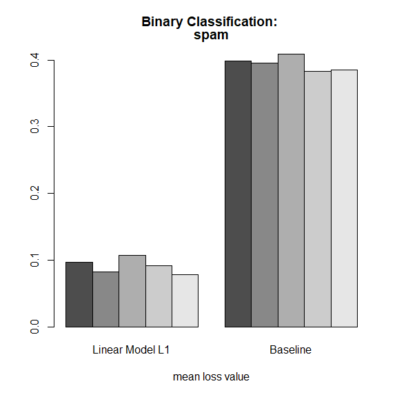

```r
# plot result
if (!data.set$is.01) {
  barplot(
    test.loss.mat,
    main = c("Square Regression: ", "spam"),
    xlab = "mean loss value",
    legend = (rownames(test.loss.mat)),
    beside = TRUE
  )
} else{
  barplot(
    test.loss.mat,
    main = c("Binary Classification: ", "spam"),
    xlab = "mean loss value",
    legend = (rownames(test.loss.mat)),
    beside = TRUE
  )
}

model.list <- LinearModelL1CV(
  X.mat = X.mat,
  y.vec = y.vec,
  # fold.vec = sample(rep(1:n.folds, l = length(y.vec))),
  n.folds = 5L,
  penalty.vec = penalty.vec,
  step.size = step.size
)
```

Comment on difference in accuracy: L1 Linear model is better than baseline

### Train/validation loss plot

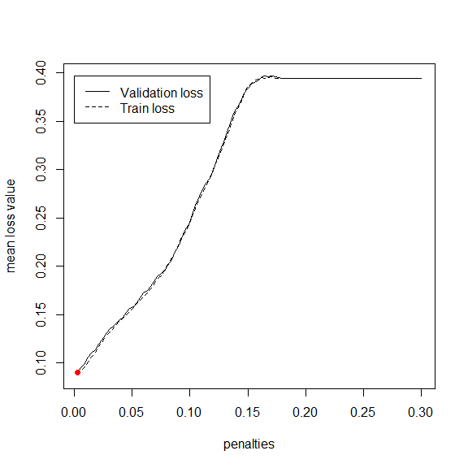

```r
matplot(
  x = penalty.vec,
  y = cbind(
    model.list$mean.validation.loss.vec,
    model.list$mean.train.loss.vec
  ),
  xlab = "penalties",
  ylab = "mean loss value",
  type = "l",
  lty = 1:2,
  pch = 15,
  col = c(17)
)


dot.x <- model.list$selected.penalty
dot.y <- model.list$mean.validation.loss.vec[which(penalty.vec == dot.x)]

matpoints(x = dot.x,
          y = dot.y,
          col = 2,
          pch = 19)
legend(
  x = 0,
  y = max(
    cbind(
      model.list$mean.validation.loss.vec,
      model.list$mean.train.loss.vec
    )
  ),
  c("Validation loss", "Train loss"),
  lty = 1:2,
  xjust = 0,
  yjust = 1
)
```

What are the optimal regularization parameters? Answer: penalty = 0.003

## Data set 2: SAheart

```r
data.name = 2
data.set <- data.list[[data.name]]

test.loss.mat <- matrix(0, nrow = n.folds, ncol = 2)
step.size <- data.set$step.size

penalty.vec = seq(data.set$lmax, data.set$lmax / 100, length.out = 100)


#Check data type here:

set.seed(1)

fold.vec <- sample(rep(1:n.folds, l = length(data.set$labels)))

for (i.fold in (1:n.folds)) {
  train.index <- fold.vec != i.fold
  test.index <- fold.vec == i.fold

  X.mat <- data.set$features
  y.vec <- data.set$labels

  X.train <- data.set$features[train.index,]
  y.train <- data.set$labels[train.index]
  X.test <- data.set$features[test.index,]
  y.test <- data.set$labels[test.index]

  result.list <- LinearModelL1CV(
    X.mat = X.train,
    y.vec = y.train,
    # fold.vec = sample(rep(1:n.folds, l = length(y.vec))),
    n.folds = 5L,
    penalty.vec = penalty.vec,
    step.size = step.size
  )

  if (data.set$is.01) {
    # binary data
    L1.predict <-
      ifelse(result.list$predict(X.test) > 0.5, 1, 0)
    L1.loss <- mean(ifelse(L1.predict == y.test, 0, 1))

    baseline.predict <- ifelse(mean(y.test) > 0.5, 1, 0)
    baseline.loss <- mean(ifelse(baseline.predict == y.test, 0, 1))

    } else{
    # regression data
    L1.predict <- result.list$predict(X.test)
    L1.loss <- mean((L1.predict - y.test) ^ 2)

    baseline.predict <- mean(y.test)
    baseline.loss <- mean((baseline.predict - y.test) ^ 2)
  }

  test.loss.mat[i.fold,] = c(L1.loss, baseline.loss)
}

colnames(test.loss.mat) <- c("Linear Model L1", "Baseline")
```

### Matrix of loss values

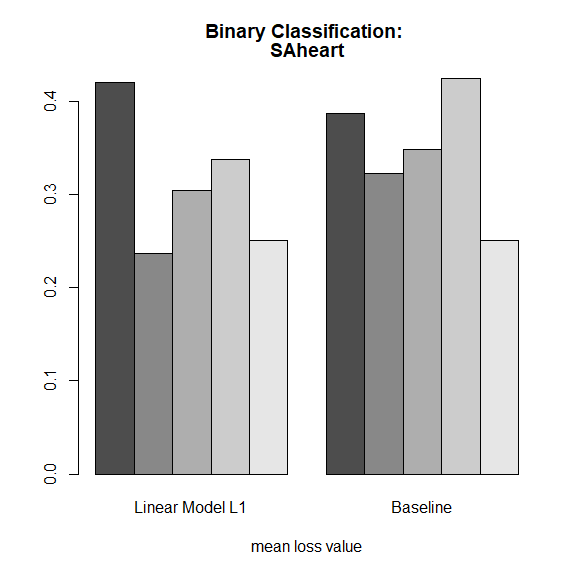

```r
# plot result
if (!data.set$is.01) {
  barplot(
    test.loss.mat,
    main = c("Square Regression: ", "SAheart"),
    xlab = "mean loss value",
    legend = (rownames(test.loss.mat)),
    beside = TRUE
  )
} else{
  barplot(
    test.loss.mat,
    main = c("Binary Classification: ", "SAheart"),
    xlab = "mean loss value",
    legend = (rownames(test.loss.mat)),
    beside = TRUE
  )
}

model.list <- LinearModelL1CV(
  X.mat = X.mat,
  y.vec = y.vec,
  # fold.vec = sample(rep(1:n.folds, l = length(y.vec))),
  n.folds = 5L,
  penalty.vec = penalty.vec,
  step.size = step.size
)
```

Comment on difference in accuracy: L1 Linear model is better than baseline

### Train/validation loss plot

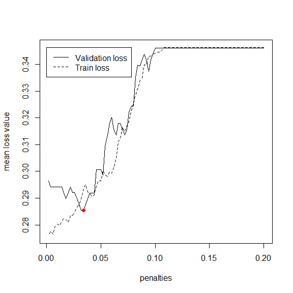

```r
matplot(
  x = penalty.vec,
  y = cbind(
    model.list$mean.validation.loss.vec,
    model.list$mean.train.loss.vec
  ),
  xlab = "penalties",
  ylab = "mean loss value",
  type = "l",
  lty = 1:2,
  pch = 15,
  col = c(17)
)


dot.x <- model.list$selected.penalty
dot.y <- model.list$mean.validation.loss.vec[which(penalty.vec == dot.x)]

matpoints(x = dot.x,
          y = dot.y,
          col = 2,
          pch = 19)
legend(
  x = 0,
  y = max(
    cbind(
      model.list$mean.validation.loss.vec,
      model.list$mean.train.loss.vec
    )
  ),
  c("Validation loss", "Train loss"),
  lty = 1:2,
  xjust = 0,
  yjust = 1
)
```

What are the optimal regularization parameters? Answer: penalty = 0.034

## Data set 3: zip.train

```r
data.name = 3
data.set <- data.list[[data.name]]

test.loss.mat <- matrix(0, nrow = n.folds, ncol = 2)
step.size <- data.set$step.size

penalty.vec = seq(data.set$lmax, data.set$lmax / 100, length.out = 100)


#Check data type here:

set.seed(1)

fold.vec <- sample(rep(1:n.folds, l = length(data.set$labels)))

for (i.fold in (1:n.folds)) {
  train.index <- fold.vec != i.fold
  test.index <- fold.vec == i.fold

  X.mat <- data.set$features
  y.vec <- data.set$labels

  X.train <- data.set$features[train.index,]
  y.train <- data.set$labels[train.index]
  X.test <- data.set$features[test.index,]
  y.test <- data.set$labels[test.index]

  result.list <- LinearModelL1CV(
    X.mat = X.train,
    y.vec = y.train,
    # fold.vec = sample(rep(1:n.folds, l = length(y.vec))),
    n.folds = 5L,
    penalty.vec = penalty.vec,
    step.size = step.size
  )

  if (data.set$is.01) {
    # binary data
    L1.predict <-
      ifelse(result.list$predict(X.test) > 0.5, 1, 0)
    L1.loss <- mean(ifelse(L1.predict == y.test, 0, 1))

    baseline.predict <- ifelse(mean(y.test) > 0.5, 1, 0)
    baseline.loss <- mean(ifelse(baseline.predict == y.test, 0, 1))

    } else{
    # regression data
    L1.predict <- result.list$predict(X.test)
    L1.loss <- mean((L1.predict - y.test) ^ 2)

    baseline.predict <- mean(y.test)
    baseline.loss <- mean((baseline.predict - y.test) ^ 2)
  }

  test.loss.mat[i.fold,] = c(L1.loss, baseline.loss)
}

colnames(test.loss.mat) <- c("Linear Model L1", "Baseline")
```

### Matrix of loss values

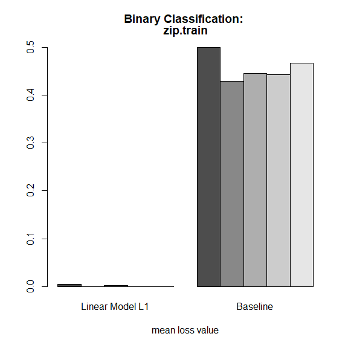

```r
# plot result
if (!data.set$is.01) {
  barplot(
    test.loss.mat,
    main = c("Square Regression: ", "zip.train"),
    xlab = "mean loss value",
    legend = (rownames(test.loss.mat)),
    beside = TRUE
  )
} else{
  barplot(
    test.loss.mat,
    main = c("Binary Classification: ", "zip.train"),
    xlab = "mean loss value",
    legend = (rownames(test.loss.mat)),
    beside = TRUE
  )
}

model.list <- LinearModelL1CV(
  X.mat = X.mat,
  y.vec = y.vec,
  # fold.vec = sample(rep(1:n.folds, l = length(y.vec))),
  n.folds = 5L,
  penalty.vec = penalty.vec,
  step.size = step.size
)
```

Comment on difference in accuracy: L1 Linear model is better than baseline

### Train/validation loss plot

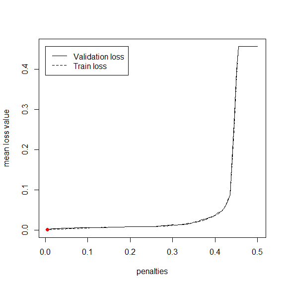

```r
matplot(
  x = penalty.vec,
  y = cbind(
    model.list$mean.validation.loss.vec,
    model.list$mean.train.loss.vec
  ),
  xlab = "penalties",
  ylab = "mean loss value",
  type = "l",
  lty = 1:2,
  pch = 15,
  col = c(17)
)


dot.x <- model.list$selected.penalty
dot.y <- model.list$mean.validation.loss.vec[which(penalty.vec == dot.x)]

matpoints(x = dot.x,
          y = dot.y,
          col = 2,
          pch = 19)
legend(
  x = 0,
  y = max(
    cbind(
      model.list$mean.validation.loss.vec,
      model.list$mean.train.loss.vec
    )
  ),
  c("Validation loss", "Train loss"),
  lty = 1:2,
  xjust = 0,
  yjust = 1
)
```

What are the optimal regularization parameters? Answer: penalty = 0.005

## Data set 4: prostate

```r
data.name = 4
data.set <- data.list[[data.name]]

test.loss.mat <- matrix(0, nrow = n.folds, ncol = 2)
step.size <- data.set$step.size

penalty.vec = seq(data.set$lmax, data.set$lmax / 100, length.out = 100)


#Check data type here:

set.seed(1)

fold.vec <- sample(rep(1:n.folds, l = length(data.set$labels)))

for (i.fold in (1:n.folds)) {
  train.index <- fold.vec != i.fold
  test.index <- fold.vec == i.fold

  X.mat <- data.set$features
  y.vec <- data.set$labels

  X.train <- data.set$features[train.index,]
  y.train <- data.set$labels[train.index]
  X.test <- data.set$features[test.index,]
  y.test <- data.set$labels[test.index]

  result.list <- LinearModelL1CV(
    X.mat = X.train,
    y.vec = y.train,
    # fold.vec = sample(rep(1:n.folds, l = length(y.vec))),
    n.folds = 5L,
    penalty.vec = penalty.vec,
    step.size = step.size
  )

  if (data.set$is.01) {
    # binary data
    L1.predict <-
      ifelse(result.list$predict(X.test) > 0.5, 1, 0)
    L1.loss <- mean(ifelse(L1.predict == y.test, 0, 1))

    baseline.predict <- ifelse(mean(y.test) > 0.5, 1, 0)
    baseline.loss <- mean(ifelse(baseline.predict == y.test, 0, 1))

    } else{
    # regression data
    L1.predict <- result.list$predict(X.test)
    L1.loss <- mean((L1.predict - y.test) ^ 2)

    baseline.predict <- mean(y.test)
    baseline.loss <- mean((baseline.predict - y.test) ^ 2)
  }

  test.loss.mat[i.fold,] = c(L1.loss, baseline.loss)
}

colnames(test.loss.mat) <- c("Linear Model L1", "Baseline")
```

### Matrix of loss values

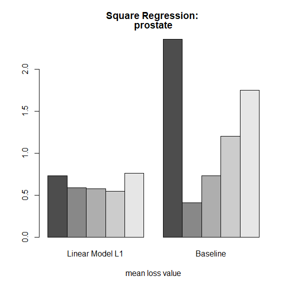

```r
# plot result
if (!data.set$is.01) {
  barplot(
    test.loss.mat,
    main = c("Square Regression: ", "prostate"),
    xlab = "mean loss value",
    legend = (rownames(test.loss.mat)),
    beside = TRUE
  )
} else{
  barplot(
    test.loss.mat,
    main = c("Binary Classification: ", "prostate"),
    xlab = "mean loss value",
    legend = (rownames(test.loss.mat)),
    beside = TRUE
  )
}

model.list <- LinearModelL1CV(
  X.mat = X.mat,
  y.vec = y.vec,
  # fold.vec = sample(rep(1:n.folds, l = length(y.vec))),
  n.folds = 5L,
  penalty.vec = penalty.vec,
  step.size = step.size
)
```

Comment on difference in accuracy: L1 Linear model is better than baseline

### Train/validation loss plot

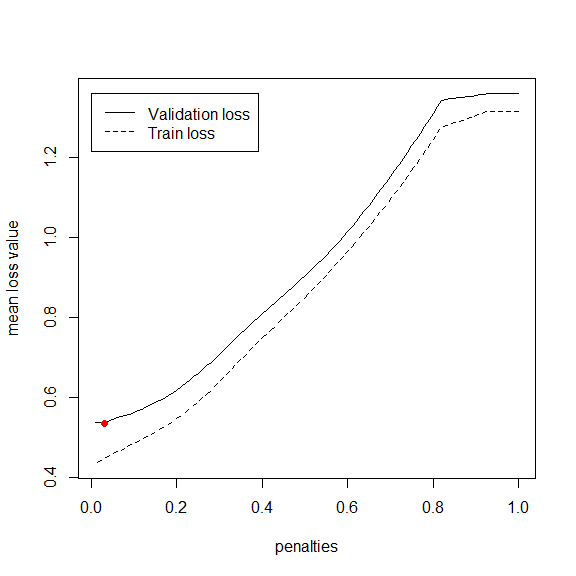

```r
matplot(
  x = penalty.vec,
  y = cbind(
    model.list$mean.validation.loss.vec,
    model.list$mean.train.loss.vec
  ),
  xlab = "penalties",
  ylab = "mean loss value",
  type = "l",
  lty = 1:2,
  pch = 15,
  col = c(17)
)


dot.x <- model.list$selected.penalty
dot.y <- model.list$mean.validation.loss.vec[which(penalty.vec == dot.x)]

matpoints(x = dot.x,
          y = dot.y,
          col = 2,
          pch = 19)
legend(
  x = 0,
  y = max(
    cbind(
      model.list$mean.validation.loss.vec,
      model.list$mean.train.loss.vec
    )
  ),
  c("Validation loss", "Train loss"),
  lty = 1:2,
  xjust = 0,
  yjust = 1
)
```

What are the optimal regularization parameters? Answer: penalty = 0.03

## Data set 5: ozone

```r
data.name = 5
data.set <- data.list[[data.name]]

test.loss.mat <- matrix(0, nrow = n.folds, ncol = 2)
step.size <- data.set$step.size

penalty.vec = seq(data.set$lmax, data.set$lmax / 100, length.out = 100)


#Check data type here:

set.seed(1)

fold.vec <- sample(rep(1:n.folds, l = length(data.set$labels)))

for (i.fold in (1:n.folds)) {
  train.index <- fold.vec != i.fold
  test.index <- fold.vec == i.fold

  X.mat <- data.set$features
  y.vec <- data.set$labels

  X.train <- data.set$features[train.index,]
  y.train <- data.set$labels[train.index]
  X.test <- data.set$features[test.index,]
  y.test <- data.set$labels[test.index]

  result.list <- LinearModelL1CV(
    X.mat = X.train,
    y.vec = y.train,
    # fold.vec = sample(rep(1:n.folds, l = length(y.vec))),
    n.folds = 5L,
    penalty.vec = penalty.vec,
    step.size = step.size
  )

  if (data.set$is.01) {
    # binary data
    L1.predict <-
      ifelse(result.list$predict(X.test) > 0.5, 1, 0)
    L1.loss <- mean(ifelse(L1.predict == y.test, 0, 1))

    baseline.predict <- ifelse(mean(y.test) > 0.5, 1, 0)
    baseline.loss <- mean(ifelse(baseline.predict == y.test, 0, 1))

    } else{
    # regression data
    L1.predict <- result.list$predict(X.test)
    L1.loss <- mean((L1.predict - y.test) ^ 2)

    baseline.predict <- mean(y.test)
    baseline.loss <- mean((baseline.predict - y.test) ^ 2)
  }

  test.loss.mat[i.fold,] = c(L1.loss, baseline.loss)
}

colnames(test.loss.mat) <- c("Linear Model L1", "Baseline")
```

### Matrix of loss values

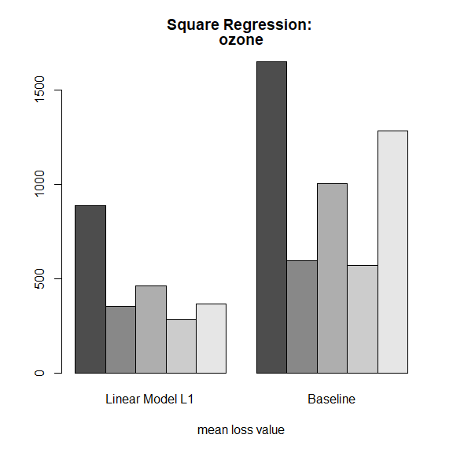

```r
# plot result
if (!data.set$is.01) {
  barplot(
    test.loss.mat,
    main = c("Square Regression: ", "ozone"),
    xlab = "mean loss value",
    legend = (rownames(test.loss.mat)),
    beside = TRUE
  )
} else{
  barplot(
    test.loss.mat,
    main = c("Binary Classification: ", "ozone"),
    xlab = "mean loss value",
    legend = (rownames(test.loss.mat)),
    beside = TRUE
  )
}

model.list <- LinearModelL1CV(
  X.mat = X.mat,
  y.vec = y.vec,
  # fold.vec = sample(rep(1:n.folds, l = length(y.vec))),
  n.folds = 5L,
  penalty.vec = penalty.vec,
  step.size = step.size
)
```

Comment on difference in accuracy: L1 Linear model is better than baseline

### Train/validation loss plot

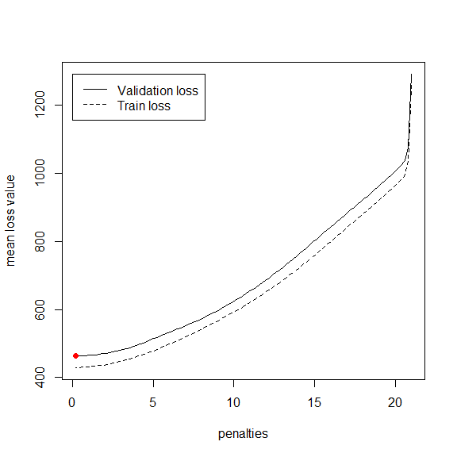

```r
matplot(
  x = penalty.vec,
  y = cbind(
    model.list$mean.validation.loss.vec,
    model.list$mean.train.loss.vec
  ),
  xlab = "penalties",
  ylab = "mean loss value",
  type = "l",
  lty = 1:2,
  pch = 15,
  col = c(17)
)


dot.x <- model.list$selected.penalty
dot.y <- model.list$mean.validation.loss.vec[which(penalty.vec == dot.x)]

matpoints(x = dot.x,
          y = dot.y,
          col = 2,
          pch = 19)
legend(
  x = 0,
  y = max(
    cbind(
      model.list$mean.validation.loss.vec,
      model.list$mean.train.loss.vec
    )
  ),
  c("Validation loss", "Train loss"),
  lty = 1:2,
  xjust = 0,
  yjust = 1
)
```

What are the optimal regularization parameters? Answer: penalty = 0.21